# Weekly report (Monday)

Fangshu Ye

5/25/2020

## Common questions for wave1 and wave2

Our interested outcomes are listed below:

- **Compliance** (Yes:1;No:0) : Does your pet/companion animal(s) influence your compliance with quarantine recommendations and requirements in your region?
- **Interact** (Yes:1;No:0) : Has COVID-19 affected your normal activities and interactions with your pet/companion animal(s)?
- **Plans** (Yes:1;No:0): Since the COVID-19 outbreak, have you made plans for caring for your pet/companion animal(s) should you become sick and unable to care for them?
- **PlansWho** (1-7:Family member; Friend; Neighbor; Animal care service provider; boarding facility; Veterinary clinic; Other): Who did you discuss this with?
- **Concern**(1-5: Not at all concerned to Extremely concerned): Overall, how concerned are you about your ability to care for your pets/companion animal(s)?
- **CCAS1-13**: (1-7: Strongly disagree to strongly agree): Question related to comfort/safe/needed/pleasurable that animal/pet provide.

#### 1.1 Delete 14 people who responded twice and their most attach pet/animal is dog or cat but have inconsistent data for **MostAttach**

#### 1.2 Determine using once or twice

Here we take **Interact** for example:

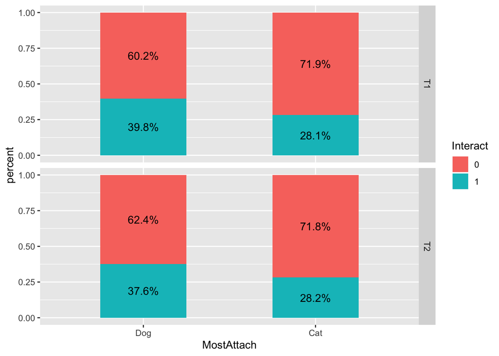

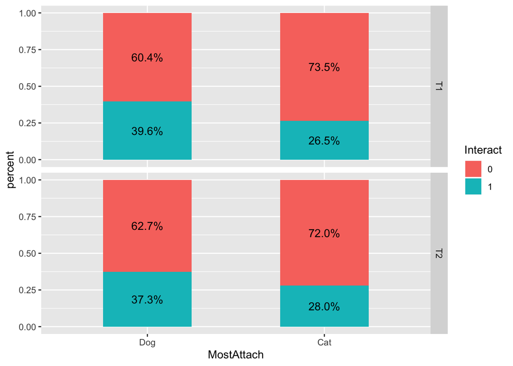

Coef of ‘MostAttachCat’, using WAVE1

|  | Estimate | Std. Error | z value | Pr(>\|z\|) |
| --- | --- | --- | --- | --- |
| include both once and twice | -0.5239306 | 0.1958483 | -2.675187 | 0.0074688 |
| only twice | -0.5946958 | 0.2223827 | -2.674200 | 0.0074908 |

Coef of ‘MostAttachCat’, using WAVE2

|  | Estimate | Std. Error | z value | Pr(>\|z\|) |
| --- | --- | --- | --- | --- |
| include both once and twice | -0.4269713 | 0.2175653 | -1.962498 | 0.0497046 |
| only twice | -0.4294575 | 0.2204008 | -1.948530 | 0.0513516 |

Coef of ‘MostAttachCat’ and ‘timeT2’, using WAVE1+WAVE2

|  | Estimate | Std. Error | z value | Pr(>\|z\|) |
| --- | --- | --- | --- | --- |
| **include both once and twice** |  |  |  |  |
| MostAttachCat | -1.0377244 | 0.3742071 | -2.7731288 | 0.0055520 |
| timeT2 | -0.0328086 | 0.2101360 | -0.1561305 | 0.8759301 |
| **only twice** |  |  |  |  |
| MostAttachCat | -1.1932423 | 0.4356537 | -2.7389700 | 0.0061632 |
| timeT2 | -0.0036641 | 0.2218225 | -0.0165181 | 0.9868210 |

**decide to use both “once” and “twice” data in the following analysis**

#### 2.1 Compliance

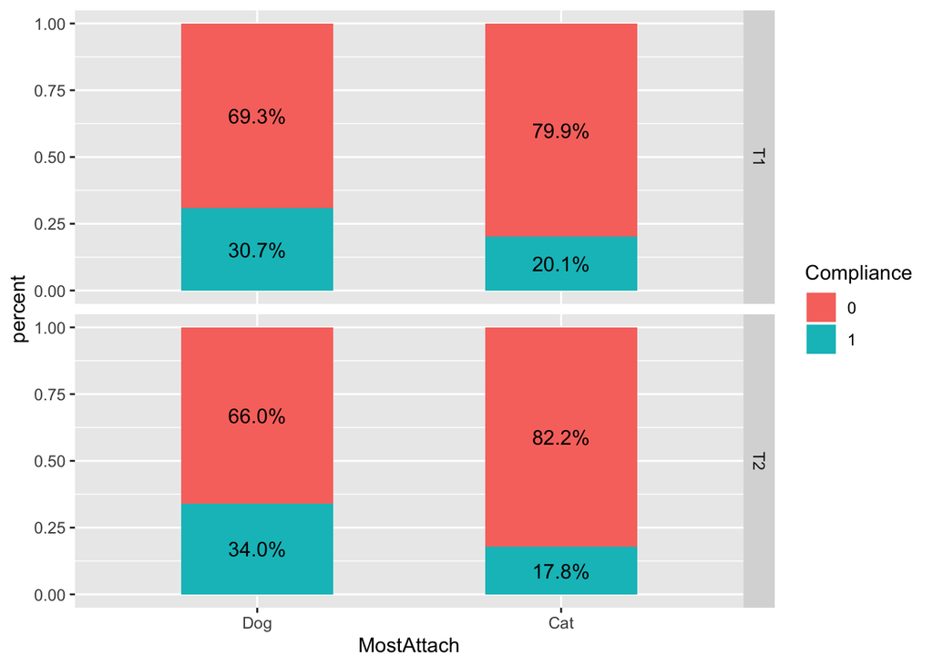

|  | Estimate | Std. Error | z value | Pr(>\|z\|) |
| --- | --- | --- | --- | --- |
| **T1: Compliance ~ MostAttach** |  |  |  |  |
| MostAttachCat | -0.5679256 | 0.2156119 | -2.6340180 | 0.0084381 |
| **T2: Compliance ~ MostAttach** |  |  |  |  |
| MostAttachCat | -0.8672498 | 0.2444806 | -3.5473156 | 0.0003892 |
| **T1+T2: Compliance ~ MostAttach + time + (1\|workerId)** |  |  |  |  |
| MostAttachCat | -1.0142730 | 0.7000990 | -1.4487566 | 0.1474056 |
| timeT2 | 1.2674832 | 0.4207932 | 3.0121283 | 0.0025942 |
| **T1+T2: Compliance ~ MostAttach + time + MostAttach*time + (1\|workerId)** |  |  |  |  |
| MostAttachCat | -0.6041538 | 0.9230904 | -0.6544904 | 0.5127959 |
| timeT2 | 1.4286438 | 0.4952426 | 2.8847353 | 0.0039174 |
| MostAttachCat:timeT2 | -0.5891788 | 0.8940369 | -0.6590095 | 0.5098897 |

#### 2.2 Interact

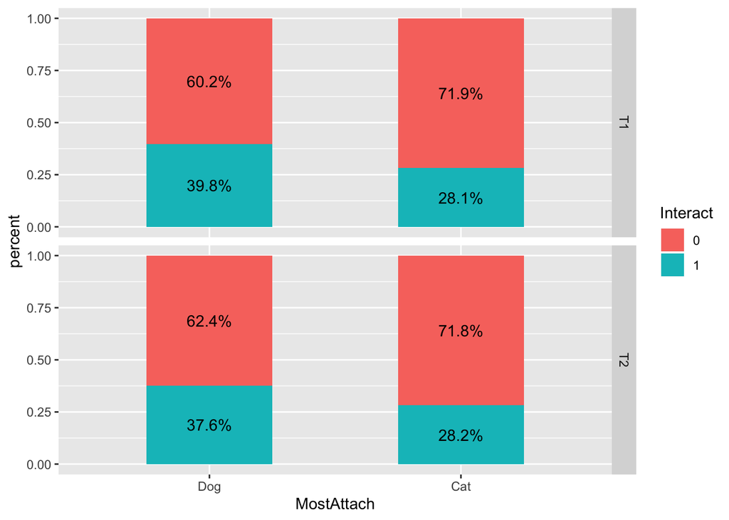

|  | Estimate | Std. Error | z value | Pr(>\|z\|) |
| --- | --- | --- | --- | --- |
| **T1: Interact ~ MostAttach** |  |  |  |  |
| MostAttachCat | -0.5239306 | 0.1958483 | -2.6751865 | 0.0074688 |
| **T2: Interact ~ MostAttach** |  |  |  |  |
| MostAttachCat | -0.4269713 | 0.2175653 | -1.9624975 | 0.0497046 |
| **T1+T2: Interact ~ MostAttach + time + (1\|workerId)** |  |  |  |  |
| MostAttachCat | -1.0377244 | 0.3742071 | -2.7731288 | 0.0055520 |
| timeT2 | -0.0328086 | 0.2101360 | -0.1561305 | 0.8759301 |

#### 2.3 Plans

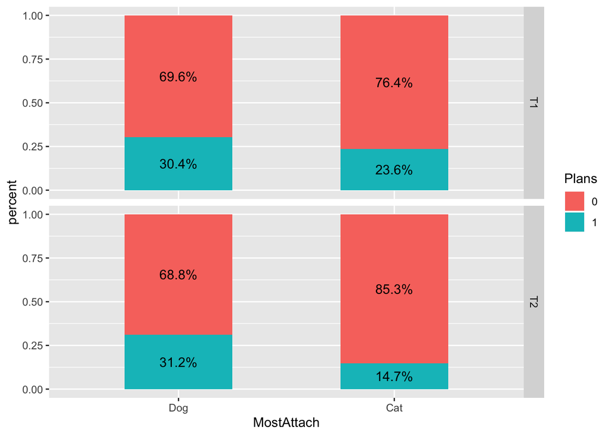

|  | Estimate | Std. Error | z value | Pr(>\|z\|) |
| --- | --- | --- | --- | --- |
| **T1: Plans ~ MostAttach** |  |  |  |  |
| MostAttachCat | -0.3463897 | 0.2077136 | -1.6676310 | 0.0953890 |
| **T2: Plans ~ MostAttach** |  |  |  |  |
| MostAttachCat | -0.9656345 | 0.2597987 | -3.7168565 | 0.0002017 |
| **T1+T2: Plans ~ MostAttach + time + (1\|workerId)** |  |  |  |  |
| MostAttachCat | -0.7530820 | 0.6423557 | -1.1723754 | 0.2410464 |
| timeT2 | -0.2981758 | 0.3603829 | -0.8273861 | 0.4080182 |
| **T1+T2: Plans ~ MostAttach + time + MostAttach*time + (1\|workerId)** |  |  |  |  |
| MostAttachCat | -0.2772341 | 0.6893804 | -0.4021497 | 0.6875739 |
| timeT2 | 0.1634316 | 0.4387137 | 0.3725244 | 0.7095025 |
| MostAttachCat:timeT2 | -1.4308664 | 0.8061123 | -1.7750212 | 0.0758944 |

#### 2.4 PlansWho

```r
table(alldata$PlansWho)
```

```
##
##   1   2   3   4   6   7
## 185  31   8   8   9   2
```

```r
table(alldata$PlansWho,alldata$MostAttach)
```

```
##
##     Dog Cat
##   1 128  57
##   2  24   7
##   3   5   3
##   4   7   1
##   6   7   2
##   7   1   1
```

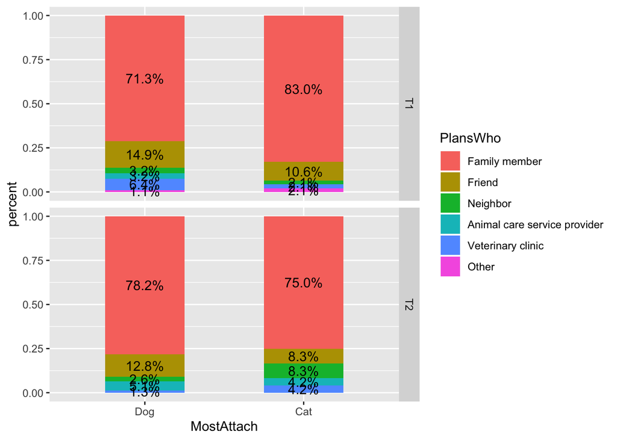

#### 2.5 Concern

##### 2.5.1 Animal Effect

H0: The distributions of **Concern** are the same for people whose most attach pet is **dog** and people whose most attach pet is **cat** when only using **WAVE1**.

```
##
##  Wilcoxon rank sum test with continuity correction
##
## data:  dat_dog and dat_cat
## W = 33446, p-value = 0.06172
## alternative hypothesis: true location shift is not equal to 0
```

H0: The distributions of **Concern** are the same for people whose most attach pet is **dog** and people whose most attach pet is **cat** when only using **WAVE2**.

```
##
##  Wilcoxon rank sum test with continuity correction
##
## data:  dat_dog and dat_cat
## W = 21881, p-value = 0.1538
## alternative hypothesis: true location shift is not equal to 0
```

H0: The distributions of **Concern** are the same for people whose most attach pet is **dog** and people whose most attach pet is **cat** when using **WAVE1** and **WAVE2**.

```
##
##  Wilcoxon rank sum test with continuity correction
##
## data:  dat_dog and dat_cat
## W = 109420, p-value = 0.01929
## alternative hypothesis: true location shift is not equal to 0
```

##### 2.5.2 Time Effect

H0: The distributions of **Concern** are the same for the **first** time people completed the survey and for the **second** time people completed the survey when their most attach pet is **dog**.

```
##
##  Wilcoxon rank sum test with continuity correction
##
## data:  as.numeric(dat_test$Concern.x) and as.numeric(dat_test$Concern.y)
## W = 22704, p-value = 0.7206
## alternative hypothesis: true location shift is not equal to 0
```

H0: The distributions of **Concern** are the same for the **first** time people completed the survey and for the **second** time people completed the survey when their most attach pet is **cat**.

```
##
##  Wilcoxon rank sum test with continuity correction
##
## data:  as.numeric(dat_test$Concern.x) and as.numeric(dat_test$Concern.y)
## W = 11460, p-value = 0.5542
## alternative hypothesis: true location shift is not equal to 0
```

#### 2.6 CCAS1-13

Using WAVE1 and WAVE2, significant results are showing as following:

**CCAS6**

```
##
##  Wilcoxon rank sum test with continuity correction
##
## data:  dat_dog and dat_cat
## W = 126378, p-value = 6.359e-11
## alternative hypothesis: true location shift is not equal to 0
```

**CCAS9**

```
##
##  Wilcoxon rank sum test with continuity correction
##
## data:  dat_dog and dat_cat
## W = 157866, p-value < 2.2e-16
## alternative hypothesis: true location shift is not equal to 0
```

**CCAS11**

```
##
##  Wilcoxon rank sum test with continuity correction
##
## data:  dat_dog and dat_cat
## W = 92722, p-value = 0.01857
## alternative hypothesis: true location shift is not equal to 0
```